# Rによる機械学習 線形回帰

Cho（ztempest0218@gmail.com）

Last Updated: 2026-10-12

**データのダウンロード**

- [Kaggle：House Prices（データページ）](https://www.kaggle.com/competitions/house-prices-advanced-regression-techniques/data)
- 直接ダウンロード：train.csv ／ test.csv
- 変数の説明（codebook）：data_description.txt

ダウンロードしたファイルは、`data/house-prices/` に保存する。

**今回の内容**

- データの分割
- 評価指標（$R^2$・RMSE・MAE）
- 住宅価格の予測演習

単回帰の説明は繰り返さない。回帰直線・切片・傾きの復習が必要な場合は、 [入門編・第11回「回帰分析の基礎」](https://ztempest0218.github.io/R-Programming/011-regression-analysis.html) を参照してほしい。

# 1 線形回帰

**線形回帰は**、機械学習でも広く使われる予測手法である。「線形」という言葉から、直線しか当てはめられないと思われがちだが、ここでいう線形とは、説明変数ではなく、**係数に対して線形であること**を指す。

たとえば、前回のガイダンスで使った9次多項式も、次のように表せる。

$$y_i = \beta_0 + \beta_1x_i + \beta_2x_i^2 + \cdots + \beta_9x_i^9 +
\varepsilon_i$$

$x$ に対して曲線を当てはめることができるが、式は、$1,x_i,x_i^2,\ldots,x_i^9$ に係数を掛けて足し合わせた形になっている。そのため、非線形な関係を当てはめていても、係数に対しては線形なモデルである。線形回帰でも、説明変数の変換によって曲線を表現できる。

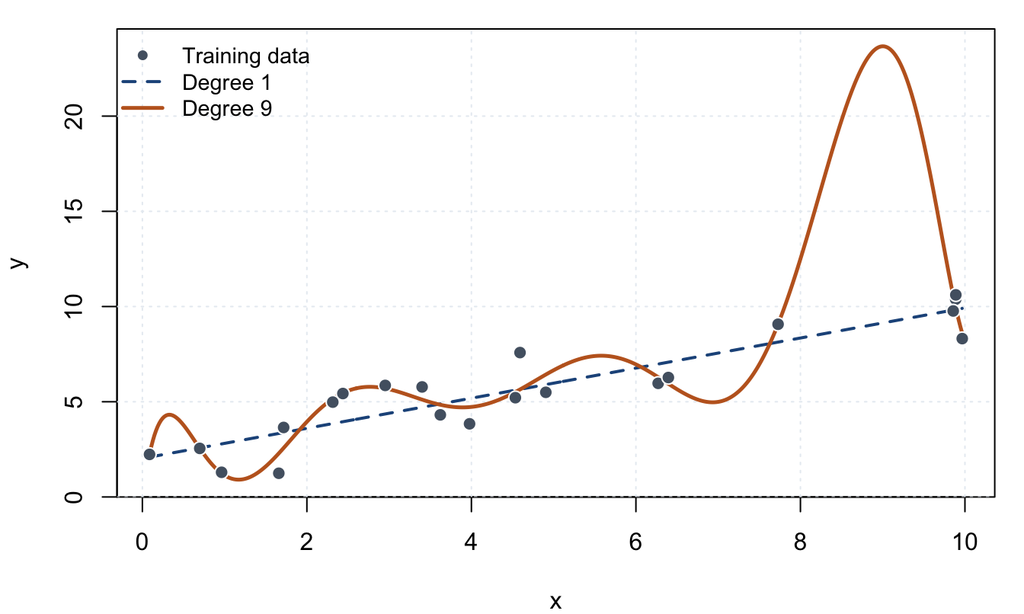

破線は直線、実線は9次多項式の当てはめであり、どちらも線形モデルである。

## 1.1 重回帰とは

一つの目的変数を**複数の説明変数**で説明・予測する線形回帰を、重回帰（multiple linear regression）という。実は、前回使った多項式回帰も、$x,x^2,\ldots,x^9$ をそれぞれ別の説明変数とみなせば、重回帰の一例である。元の変数は一つでも、それを変換した複数の項を使って予測している。

説明変数が $p$ 個あるとき、重回帰モデルは次のように表される。

$$y_i = \beta_0 + \beta_1 x_{i1} + \cdots + \beta_p x_{ip} +
\varepsilon_i,
\qquad i=1,\ldots,n$$

$y_i$ は目的変数、$x_{ij}$ は第 $j$ 番目の説明変数、$\beta_0$ は切片、$\beta_j$ は回帰係数、$\varepsilon_i$ は誤差項である。$n$ は学習に使う観測数を表す。

係数は、**残差平方和を最小にする最小二乗法（OLS）**で推定する。

$$(\hat\beta_0,\hat\beta_1,\ldots,\hat\beta_p)
=\operatorname*{arg\,min}_{\beta_0,\beta_1,\ldots,\beta_p}
\sum_{i=1}^{n}
\left(y_i-\beta_0-\sum_{j=1}^{p}\beta_jx_{ij}\right)^2$$

推定した係数を使うと、予測値は $\hat y_i=\hat\beta_0+\sum_{j=1}^{p}\hat\beta_jx_{ij}$ となり、実際の値との差 $y_i-\hat y_i$ が残差である。

### 1.1.1 補足：経済学の非線形モデルを線形に変換する

コブダグラス型生産関数では、生産量 $Y$ を資本 $K$、労働 $L$、生産性 $A$ で表す。

$$Y = AK^{\alpha}L^{\beta}$$

$A$ を各観測で共通と仮定し、両辺の自然対数を取って誤差項を加えると、次の重回帰モデルになる。

$$\log Y_i = \beta_0 + \alpha\log K_i + \beta\log L_i + \varepsilon_i,
\qquad \beta_0=\log A$$

経済モデルを重回帰の形に書き換えれば、実際のデータから係数を推定できる。

## 1.2 機械学習におけるデータの使い方

機械学習では、既存データへの当てはまりだけでなく、**未知のデータに対する予測性能（out-of-sample performance）**が重要である。そのため、正解付きのデータを学習用データ（training data）とテストデータ（test data）に分け、テストデータで予測値 $\hat{y}$ と正解 $y$ を比較する。

正解付きデータ \((X,y)\)

二つに分割

train：学習用  
説明変数 \(X\) と正解 \(y\)

test：評価用  
説明変数 \(X\) と正解 \(y\)

学習

評価

モデル

予測精度を評価  
予測 \(\hat{y}\) と正解 \(y\)

予測 \(\hat{y}\)

正解・評価結果を見てモデルを調整するおそれ

注：オーソドックスな機械学習のテキストの場合。

テストデータは、モデルの予測性能を独立に評価するために使う。しかし、分析者自身が正解を確認できる場合、データを分けるだけでは、答えを見てモデルを調整することを防げない。こうした調整は**データ漏洩**（data leakage）につながり、テストデータで高い予測精度が得られても、**未知のデータでも再現されるとは限らない**。

たとえば、自動運転では、学習データで高い精度を示しても、実際の複雑な道路状況で判断を誤れば、人命に関わる事故につながりうる。データ漏洩は予測性能を過大評価する原因の一つであり、学習時の性能だけで実際の場面でも通用すると判断することはできない。

Kaggleのようなデータサイエンスのコンペティションサイトでは、参加者が共通のデータを使って予測精度を競う。採点用のテストデータ（test data）は第三者である運営側が管理し、参加者には説明変数 $X$ のみを公開する。正解 $y$ は非公開のため、参加者が答えを直接見てモデルを調整することはできない。

テストデータの正解を使って自分で予測性能を確かめられないため、参加者は正解付きの学習用データ（training data）の一部を、検証用データ（validation data）として取り分ける必要がある。残りの学習用データでモデルを学習させ、検証用データで比較・調整する。テストデータは、モデル確定後の最終評価に使う。自分で正解付きのデータを持っている場合も、モデルの選択・調整を行うなら、三つに分ける方法が勧められる。

[figure not shown]

Kaggle の train.csv：正解あり

Kaggle の test.csv

分割

train：学習用  
\(X\) と \(y\)

validation：検証用  
\(X\) と \(y\)

test：最終評価用  
\(X\) のみ（\(y\) は非公開）

モデルを学習

モデルを比較・調整

予測を提出・採点

モデル確定後に独立評価

調整して再学習

注：テストデータを第三者が管理する場合。

## 1.3 特徴量エンジニアリング

機械学習では、予測に使う説明変数 $X$ を**特徴量（feature）**と呼ぶ。元のデータを加工し、モデルが予測に使いやすい特徴量を作ることを、**特徴量エンジニアリング（feature engineering）**という。先ほどの多項式や対数変換も、その例である。

| 加工の例 | 作る特徴量 |
| --- | --- |
| 多項式 | $x$ から $x^2, x^3, \ldots$ を作る |
| 対数変換 | 面積 $x$ から $\log(x)$ を作る（$x>0$） |
| 変数の組み合わせ | 売却年 $-$ 建築年から築年数を作る |
| カテゴリの数値化 | 建物の種類を表す0・1のダミー変数を作る |

線形回帰でも、変数を二乗したり対数を取ったりすれば、曲線的な関係を表せる。ただし、変数を増やすだけで予測が良くなるわけではない。どの変数を使うかは、検証用データで予測性能を比べて決める。

その前に、**データの前処理**が必要である。データを読み込んだら、欠損値（missing）、重複、入力ミス、単位やデータ型を確認する。欠損値に気づかず回帰すると、エラーが出たり、一部の観測が自動的に除外されたりする。どのアルゴリズムを使うかを考える前に、まずデータの中身を確認しよう。

どの変数を使い、どう加工するかを考えるときには、経済学などで学んだ理論が使える。入門の授業でも述べたが、変数を適当に回帰式に入れると、結果は出ても何を推定したのか分からなくなる。その変数がなぜ目的変数と関係するのかを考えて選ぶ。

たとえば、体重と身長から肥満の有無を予測するとする。体重を $w$（kg）、身長を $h$（m）とすれば、$\mathrm{BMI}=w/h^2$ を計算できる。日本の成人ではBMIが25以上を肥満とするため、この基準で付けたラベルなら、BMIだけで判定できる（[日本肥満学会](https://www.jasso.or.jp/contents/wod/index.html)）。判定基準を知っていれば、複雑なモデルを使う必要はない。

都道府県別の出生率を予測する場合も、集めたデータを全部回帰式に入れればよいわけではない。Beckerの家計内生産モデルでは、比較優位に基づく分業が結婚の利益を生むと考える（[Becker, 1973](https://www.journals.uchicago.edu/doi/10.1086/260084)）。この理論を参考にすれば、男女の賃金を別々に入れるだけでなく、賃金比を作ることも考えられる。

機械学習や深層学習、大規模言語モデルでは、アルゴリズムの性能ばかりに注目が集まりがちである。しかし、どの情報を使い、どう変数として表すかという**特徴量エンジニアリング**も重要であり、予測では精度に、因果推論では効果の推定の妥当性に関わる。

## 1.4 回帰モデルの評価指標

まず、計算を確認するための6件のデータを作る。以下では、このデータを使って残差と各評価指標の計算を確認する。

```r
rm(list = ls())

demo <- data.frame(
  x = 1:6,
  y = c(5, 3, 4, 5, 6, 10)
)
demo
```

| x | y |
| --- | --- |
| 1 | 5 |
| 2 | 3 |
| 3 | 4 |
| 4 | 5 |
| 5 | 6 |
| 6 | 10 |

予測のずれを測る前に、残差 $e_i=y_i-\hat{y}_i$ を確認する。点が実際の値、直線が予測値、縦線が残差を表す。直線より上の点では正、下の点では負になる。

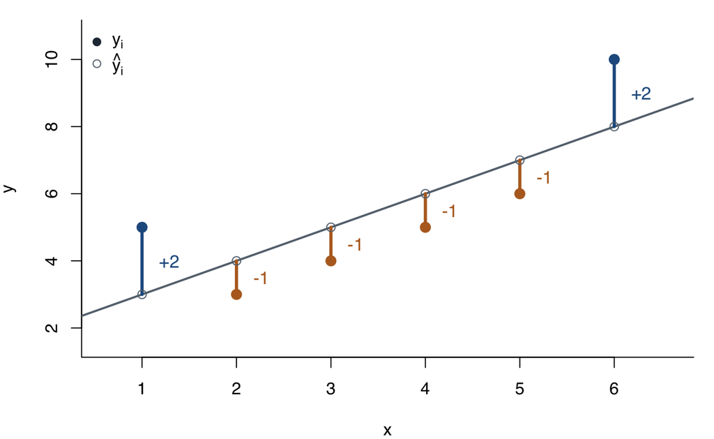

**切片を含むOLSでは、学習データの残差の合計は0になる。**

$$\sum_{i=1}^{n}(y_i-\hat{y}_i)=0$$

評価用データでは0になるとは限らないが、正負が相殺する問題は同じである。そのため、ずれの大きさは数学的に $|e_i|$ や $e_i^2$ を使って測る必要がある。ここで計算して保存し、後の評価指標の計算に使う。

各観測の残差、その二乗と絶対値を並べる。最後の列は、平均値からの偏差の二乗である。

```r
fit <- lm(y ~ x, data = demo)
pred <- predict(fit)
resid <- demo$y - pred
abs_resid <- abs(resid)
squared_resid <- resid^2

details <- data.frame(
  x = demo$x,
  y = demo$y,
  y_bar = mean(demo$y),
  y_hat = pred,
  e = resid,
  e_squared = squared_resid,
  abs_e = abs_resid,
  centered_squared = (demo$y - mean(demo$y))^2
)
knitr::kable(details, digits = 2, row.names = FALSE,
             col.names = c("$x_i$", "$y_i$", "$\\bar{y}$", "$\\hat{y}_i$", "$e_i$",
                           "$e_i^2$", "$\\lvert e_i \\rvert$", "$(y_i-\\bar{y})^2$"))
```

| $x_i$ | $y_i$ | $\bar{y}$ | $\hat{y}_i$ | $e_i$ | $e_i^2$ | $\lvert e_i \rvert$ | $(y_i-\bar{y})^2$ |
| --- | --- | --- | --- | --- | --- | --- | --- |
| 1 | 5 | 5.5 | 3 | 2 | 4 | 2 | 0.25 |
| 2 | 3 | 5.5 | 4 | -1 | 1 | 1 | 6.25 |
| 3 | 4 | 5.5 | 5 | -1 | 1 | 1 | 2.25 |
| 4 | 5 | 5.5 | 6 | -1 | 1 | 1 | 0.25 |
| 5 | 6 | 5.5 | 7 | -1 | 1 | 1 | 0.25 |
| 6 | 10 | 5.5 | 8 | 2 | 4 | 2 | 20.25 |

### 1.4.1 決定係数：$R^2$

統計学・計量経済学では、回帰モデルの当てはまりを表す**決定係数 $R^2$**をよく使う。観測数を $n$、実際の値を $y_i$、予測値を $\hat{y}_i$ とすると、次のように計算する。

$$R^2=1-\frac{\sum_{i=1}^{n}(y_i-\hat{y}_i)^2}
{\sum_{i=1}^{n}(y_i-\bar{y})^2},
\qquad \bar{y}=\frac{1}{n}\sum_{i=1}^{n}y_i$$

$\displaystyle \hat{y}_i=\bar{y}$

$\displaystyle \hat{y}_i=2+x_i$

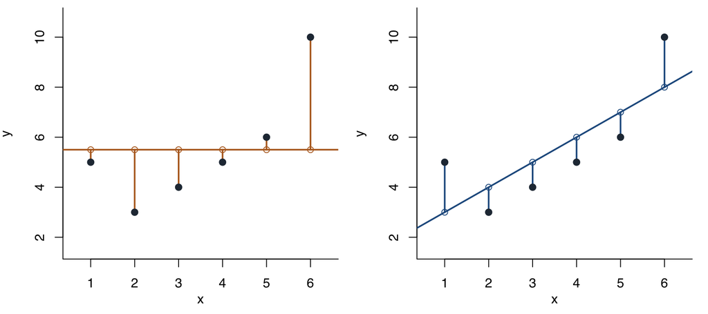

$\displaystyle \mathrm{TSS}=\sum_{i=1}^{n}(y_i-\bar{y})^2=29.5$

$\displaystyle \mathrm{SSE}=\sum_{i=1}^{n}(y_i-\hat{y}_i)^2=12$

左の **TSS（Total Sum of Squares：全変動・総平方和）**は、実際の値が平均値のまわりにどれだけ散らばっているかを表す。すべての観測の予測値を平均値とした場合の誤差平方和でもある。右の **SSE（Sum of Squared Errors：残差平方和）**は、回帰モデルの残差を二乗して合計した値である。

$$R^2=1-\frac{\mathrm{SSE}}{\mathrm{TSS}}
=1-\frac{12}{29.5}\approx 0.593$$

```r
sse <- sum(squared_resid)
tss <- sum((demo$y - mean(demo$y))^2)
r2 <- 1 - sse / tss
c(SSE = sse, TSS = tss, R2 = r2)
```

```
##        SSE        TSS         R2
## 12.0000000 29.5000000  0.5932203
```

$R^2$ は、**モデルの当てはまりの良さを表す指標**であり、値が大きいほど当てはまりが良い。具体的には、平均値だけを使うモデルと比べて、残差平方和がどれだけ減ったかを表す。$R^2=1$ は残差がすべて0、$R^2=0$ は平均値だけを使うモデルと残差平方和が同じであることを意味する。

切片を含む通常のOLSでは、学習データの $R^2$ は $0\leq R^2\leq1$ となる。一方、別のデータを評価する際も、学習データで推定した係数をそのまま使うため、$R^2$ が負になることがある。

次のシミュレーションで、$R^2$ と点の散らばり方の関係を確認する。0から1まで、0.1刻みで選べる。

\(R^2\)：0.5

0.00.10.20.30.40.50.60.70.80.91.0

OLS：\(\hat{y}\)平均：\(\bar{y}\)

\(R^2\) = SSE = TSS =

なお、因果推論では、$R^2$ の高さで分析の妥当性を判断することはできない。$R^2=1$ でも、政策の因果効果を正しく推定できているとは限らない。因果関係の説明が誤っていても予測に役立つ場合はあるため、政策効果を評価する際に、当てはまりの良さを因果効果の根拠にしてはいけない。

### 1.4.2 MSE・RMSE：平均二乗誤差とその平方根

**MSE（mean squared error：平均二乗誤差）**は、予測誤差を二乗して平均した値である。同じ学習データで残差平方和を最小にするOLSは、学習データのMSEも最小にする。

$$\mathrm{MSE}=\frac{1}{n}\sum_{i=1}^{n}(y_i-\hat{y}_i)^2$$

MSEの単位は目的変数の単位の二乗になる。その平方根を取った **RMSE（root mean squared error：二乗平均平方根誤差）**なら、価格ならドルという元の単位で予測のずれを示せる。

$$\mathrm{RMSE}=\sqrt{\mathrm{MSE}}$$

どちらも小さいほど良く、大きなずれを重く評価する。同じ評価データなら、MSEとRMSEによるモデルの順位は一致する。

6件の残差平方和は12なので、$\mathrm{MSE}=12/6=2$、$\mathrm{RMSE}=\sqrt{2}\approx1.414$ となる。

```r
mse <- mean(squared_resid)
rmse <- sqrt(mse)
c(MSE = mse, RMSE = rmse)
```

```
##      MSE     RMSE
## 2.000000 1.414214
```

先ほどのシミュレーションと同じ仮想データを使う。点は固定し、予測直線の切片と傾きを動かして、MSE・RMSEの変化を確認しよう。

切片 \(a\)：0.00 傾き \(b\)：0.71

黒点：実際の値 青線：\(\hat{y}=a+bx\) 縦線：残差  
オレンジ色の点：切片 \((0,a)\)

SSE = \(n=40\)  
MSE = RMSE =

### 1.4.3 MAE：平均絶対誤差

$$\mathrm{MAE}=\frac{1}{n}\sum_{i=1}^{n}|y_i-\hat{y}_i|$$

**MAE（mean absolute error）**は、予測誤差の絶対値の平均である。RMSEより一部の大きな誤差の影響を受けにくい。

残差の絶対値の合計は8なので、$\mathrm{MAE}=8/6\approx 1.333$ となる。

```r
mae <- mean(abs_resid)
mae
```

```
## [1] 1.333333
```

## 1.5 指標の特徴と使い分け

| 指標 | 値の見方 | 単位 | 特徴 |
| --- | --- | --- | --- |
| $R^2$ | 大きいほど良い | なし | 通常0〜1の相対指標（評価用データでは負もありうる） |
| RMSE | 小さいほど良い | 目的変数と同じ | 大きな予測のずれに強いペナルティ |
| MAE | 小さいほど良い | 目的変数と同じ | 極端なずれの影響が比較的小さい |

$R^2$ は、平均値だけで予測する場合を基準にした**相対的な指標**である。1に近いほど当てはまりが良く、0なら平均値による予測と同じなので、比較の基準が分かりやすい。ただし、評価用データでは負になることもある。

RMSE・MAEは目的変数と同じ単位でずれを表すため、数値だけでは予測性能の良し悪しを判断しにくい。たとえば、RMSEが1万ドルでも、住宅価格の規模や必要な精度によって評価は変わる。**同じ評価データ・同じ単位**で、別のモデルや他の分析者の結果と比較する。

同じ評価データで比較すると、MSE・RMSEが小さいモデルほど $R^2$ は大きくなる。そのため、これらの指標で最も良いと評価されるモデルは同じだが、MAEでは別のモデルが選ばれることがある。

## 1.6 機械学習の手順

データを分割し、学習・予測・評価を行う。検証用データでの結果を見て特徴量やモデルの設定を調整し、再び学習する。この調整をチューニングという。テストデータはモデル確定後の最終評価に使う。

[figure not shown]

# 2 線形回帰による住宅価格の予測

## 2.1 使用するデータ

本講義では、Kaggleの [House Prices: Advanced Regression Techniques](https://www.kaggle.com/competitions/house-prices-advanced-regression-techniques) で使われている住宅データを例に考える。対象は米国アイオワ州Amesの住宅であり、住宅の属性から成約価格 `SalePrice` を予測する課題である。Wooldridgeの『Introductory Econometrics: A Modern Approach』でも、住宅データによる重回帰や多重共線性が取り上げられている。

データは `data/house-prices/` に保存してある。

各変数の意味やカテゴリの定義は、コードブック（data_description.txt）で確認できる。

| ファイル | 観測数 | 内容 |
| --- | --- | --- |
| `train.csv` | 1,460 | 住宅の属性と成約価格 `SalePrice` |
| `test.csv` | 1,459 | 住宅の属性のみ。成約価格は**非公開** |

### 2.1.1 データを読み込む

`train.csv` には、79個の説明変数に加えて、識別番号 `Id` と目的変数 `SalePrice` の計81列がある。`Id` は住宅を識別するための番号として扱い、説明変数には含めない。

今回は、目的変数の `SalePrice` と、説明変数として使う `GrLivArea`・`OverallQual`・`YearBuilt`・`BldgType` だけを取り出す。`Id` は住宅を識別するために残し、回帰には使わない。

| 変数 | 内容 | 単位・尺度 |
| --- | --- | --- |
| `SalePrice` | 成約価格（目的変数） | 米ドル |
| `GrLivArea` | 地上部分の居住面積 | 平方フィート |
| `OverallQual` | 建材・仕上げの総合品質 | 1〜10の評価 |
| `YearBuilt` | 建築年 | 西暦 |
| `BldgType` | 建物の種類 | カテゴリ変数（`1Fam`：一戸建てなど） |

```r
rm(list = ls())
library(dplyr)

# 読み込む前に、dataフォルダがある場所を作業ディレクトリに設定する（setwd()）
house_prices <- read.csv("data/house-prices/train.csv",
                         stringsAsFactors = FALSE,
                         check.names = FALSE)

data <- house_prices %>%
  select(Id, SalePrice, GrLivArea, OverallQual, YearBuilt, BldgType)

head(data)
```

|  | Id | SalePrice | GrLivArea | OverallQual | YearBuilt | BldgType |
| --- | --- | --- | --- | --- | --- | --- |
| 1 | 1 | 208500 | 1710 | 7 | 2003 | 1Fam |
| 2 | 2 | 181500 | 1262 | 6 | 1976 | 1Fam |
| 3 | 3 | 223500 | 1786 | 7 | 2001 | 1Fam |
| 4 | 4 | 140000 | 1717 | 7 | 1915 | 1Fam |
| 5 | 5 | 250000 | 2198 | 8 | 2000 | 1Fam |
| 6 | 6 | 143000 | 1362 | 5 | 1993 | 1Fam |

たとえば、最初の住宅の居住面積は 1710 平方フィート、品質評価は 7、建築年は 2003 年、成約価格は 208,500 ドルである。

```r
colSums(is.na(data))
```

```
##          Id   SalePrice   GrLivArea OverallQual   YearBuilt    BldgType
##           0           0           0           0           0           0
```

```r
# 各変数のデータ型を確認する
sapply(data, class)
```

```
##          Id   SalePrice   GrLivArea OverallQual   YearBuilt    BldgType
##   "integer"   "integer"   "integer"   "integer"   "integer" "character"
```

今回取り出したデータには欠損値がない。

`BldgType` は文字列型（`character`）で読み込まれている。建物の種類を表すカテゴリ変数なので、因子型（`factor`）に変換して使う。比較の基準は `1Fam` とする。

```r
data <- data %>%
  mutate(BldgType = relevel(factor(BldgType), ref = "1Fam"))
class(data$BldgType)
```

```
## [1] "factor"
```

なお、Kaggleの `test.csv` には正解の価格が含まれない。そのため、授業内で予測誤差を確かめる際には、価格が分かっている `train.csv` をさらに学習用と検証用に分ける。

## 2.2 データの分割

先ほど作成した `data` オブジェクト（1,460件）をランダムに分割し、80%を学習用データ `train`、20%を検証用データ `validation` とする。どちらも正解価格を含み、Kaggleの `test.csv` とは別である。

`set.seed(2026)` で乱数シードを固定し、同じ分割を再現できるようにする。

```r
# 同じ分割を再現できるように乱数シードを固定する
set.seed(2026)

# 全行の番号から80%をランダムに選ぶ
train_index <- sample(nrow(data), size = 0.8 * nrow(data))

# 選んだ行を学習用にする
train <- data[train_index, ]

# 残りの行を検証用にする（マイナスは指定した行を除くという意味）
validation <- data[-train_index, ]

# それぞれの観測数を確認する
c(train = nrow(train), validation = nrow(validation))
```

```
##      train validation
##       1168        292
```

ここでは、2006〜2010年の住宅取引をプールした横断面データ（pooled cross-sectional data）として、住宅価格を予測する。実際の価格には各年の景気などのマクロ経済動向も影響するが、ここではその違いを考慮しない。

また、時系列データで将来を予測する場合、ランダムに分割すると未来の情報を使って過去を予測してしまう。そのため、データを分割する際には、データ構造を必ず確認すること。

## 2.3 線形回帰モデルを学習させる

居住面積・品質・建築年・建物の種類を説明変数として使う。`BldgType` はカテゴリ変数として扱い、`1Fam` を基準にする。

```r
# trainデータを使い、lm()で線形回帰モデルを当てはめる
fit <- lm(SalePrice ~ GrLivArea + OverallQual + YearBuilt + BldgType,
          data = train)
summary(fit)
```

```
##
## Call:
## lm(formula = SalePrice ~ GrLivArea + OverallQual + YearBuilt +
##     BldgType, data = train)
##
## Residuals:
##     Min      1Q  Median      3Q     Max
## -375574  -21136   -2392   16511  301737
##
## Coefficients:
##                  Estimate Std. Error t value Pr(>|t|)
## (Intercept)    -1.160e+06  9.508e+04 -12.202  < 2e-16 ***
## GrLivArea       5.616e+01  2.951e+00  19.027  < 2e-16 ***
## OverallQual     2.530e+04  1.319e+03  19.187  < 2e-16 ***
## YearBuilt       5.607e+02  4.998e+01  11.217  < 2e-16 ***
## BldgType2fmCon -4.185e+03  7.971e+03  -0.525 0.599699
## BldgTypeDuplex -2.511e+04  6.711e+03  -3.742 0.000192 ***
## BldgTypeTwnhs  -4.569e+04  6.900e+03  -6.622 5.40e-11 ***
## BldgTypeTwnhsE -2.111e+04  4.659e+03  -4.530 6.51e-06 ***
## ---
## Signif. codes:  0 '***' 0.001 '**' 0.01 '*' 0.05 '.' 0.1 ' ' 1
##
## Residual standard error: 39730 on 1160 degrees of freedom
## Multiple R-squared:  0.7506, Adjusted R-squared:  0.7491
## F-statistic: 498.8 on 7 and 1160 DF,  p-value: < 2.2e-16
```

`summary()` で係数や決定係数を確認できる。`Multiple R-squared` は**学習用データの $R^2$**であり、検証用データでの予測性能ではない。

推定した回帰式は、次のように表せる。

$$\hat{y}_i
= \hat{\beta}_0
+ \hat{\beta}_1\mathrm{GrLivArea}_i
+ \hat{\beta}_2\mathrm{OverallQual}_i
+ \hat{\beta}_3\mathrm{YearBuilt}_i
+ \sum_{k=1}^{4}\hat{\gamma}_k D_{ik}$$

$D_{ik}$ は、`1Fam` を基準とした建物の種類の4個のダミー変数である。$\beta$ と $\gamma$ の推定値は、回帰結果の `Estimate` 列に表示されている。これらが、学習用データからモデルが学習したパラメータである。検証用データの説明変数 $X$ をこの式に代入すれば、予測価格 $\hat{y}$ が得られる。

## 2.4 検証用データの価格を予測する

まず、検証用データ `validation` の先頭を確認する。これは予測前の元データであり、`SalePrice` は実際の成約価格である。

```r
head(validation)
```

|  | Id | SalePrice | GrLivArea | OverallQual | YearBuilt | BldgType |
| --- | --- | --- | --- | --- | --- | --- |
| 1 | 1 | 208500 | 1710 | 7 | 2003 | 1Fam |
| 3 | 3 | 223500 | 1786 | 7 | 2001 | 1Fam |
| 13 | 13 | 144000 | 912 | 5 | 1962 | 1Fam |
| 16 | 16 | 132000 | 854 | 7 | 1929 | 1Fam |
| 20 | 20 | 139000 | 1339 | 5 | 1958 | 1Fam |
| 24 | 24 | 129900 | 1060 | 5 | 1976 | TwnhsE |

`predict()` の第1引数 `fit` は学習済みのモデル、`newdata = validation` は予測対象のデータを指定する引数である。`validation` の説明変数・特徴量の数値を使い、各住宅の予測価格を計算する。`SalePrice` は予測の計算には使わず、後で予測値と比較する。

```r
pred_validation <- predict(fit, newdata = validation)

# 実際の価格・予測価格・予測誤差を用意する
actual <- validation$SalePrice
predicted <- pred_validation
error <- actual - predicted

prediction_table <- data.frame(
  Id = validation$Id,
  Actual = actual,
  Predicted = predicted,
  Error = error
)
head(prediction_table)
```

|  | Id | Actual | Predicted | Error |
| --- | --- | --- | --- | --- |
| 1 | 1 | 208500 | 236063.8 | -27563.7827 |
| 3 | 3 | 223500 | 239210.3 | -15710.2881 |
| 13 | 13 | 144000 | 117662.3 | 26337.7344 |
| 16 | 16 | 132000 | 146505.2 | -14505.2379 |
| 20 | 20 | 139000 | 139398.1 | -398.1042 |
| 24 | 24 | 129900 | 112717.0 | 17182.9892 |

`Error` は予測誤差（実際の価格 − 予測価格）である。正なら過小予測、負なら過大予測を表す。価格と誤差の単位は米ドルである。

$y_i-\hat{y}_i$ は、学習用データでは残差、検証用データでは予測誤差と呼ぶ。どちらも、モデルの誤差項 $\varepsilon_i$ そのものではない。

## 2.5 予測性能を評価する

### 2.5.1 検証用データでR²・RMSE・MAEを計算する

計算を簡単にするため、差の二乗和を求める自作関数 `ss()` を作る。SSEやTSSの計算に使える。

```r
# 差の二乗和を計算する関数
ss <- function(a, b) sum((a - b)^2)
```

予測値からのずれの二乗和（SSE）と、平均値からのずれの二乗和（TSS）を求め、その比から $R^2$ を計算する。

```r
# SSE：予測値からのずれの二乗和
sse <- ss(actual, predicted)

# TSS：平均値からのずれの二乗和
tss <- ss(actual, mean(actual))

# 決定係数
r_squared <- 1 - sse / tss
```

RMSEはSSEを観測数で割って平方根を取り、MAEは予測誤差の絶対値を平均して求める。

```r
# RMSE：二乗和を観測数で割り、平方根を取る
rmse <- sqrt(sse / nrow(validation))

# MAE：予測誤差の絶対値を平均する
mae <- mean(abs(error))
```

三つの指標を `metrics` にまとめる。

```r
# 三つの指標をまとめる
metrics <- data.frame(R2 = r_squared, RMSE = rmse, MAE = mae)
metrics
```

| R2 | RMSE | MAE |
| --- | --- | --- |
| 0.7495739 | 40019.25 | 26180.43 |

$R^2$ は **0.75**、RMSEは約 **40,019 ドル**、MAEは約 **26,180 ドル**である。$R^2$ は大きいほど、RMSE・MAEは小さいほど良い。単位や尺度が異なるため、三つの値の大小を直接比較するものではない。

Kaggleの評価指標はコンペごとに異なるが、この住宅価格コンペでは、価格の対数に対するRMSEが小さいほど予測性能が高いと評価される（[評価方法](https://www.kaggle.com/competitions/house-prices-advanced-regression-techniques/overview/evaluation)）。

## 2.6 予測誤差の分析

検証用データで予測のずれを図で確認する。左図は実際の価格と予測価格の比較で、対角線に近いほど予測が正確である。右図は予測価格と予測誤差の関係で、ずれに規則的な傾向がないかを見る。金額は千ドル単位で示す。

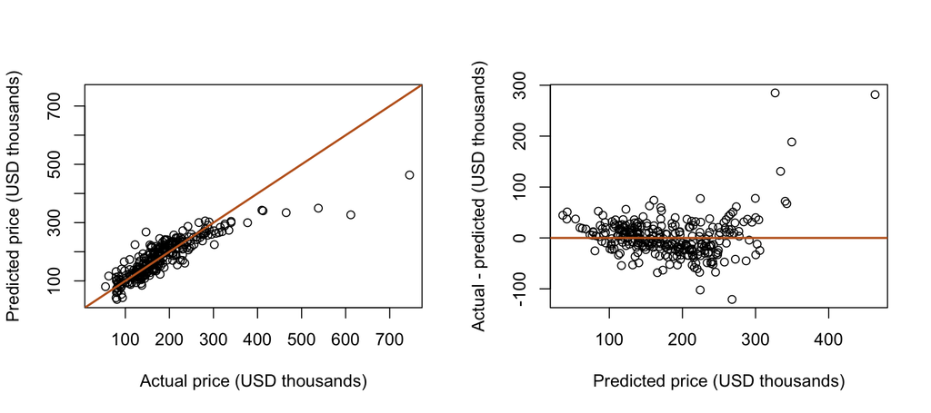

```r
# 二つの図を横に並べる
par(mfrow = c(1, 2))

# 左図：実際の価格と予測価格（千ドル単位）
limits <- range(c(actual, predicted)) / 1000
plot(actual / 1000, predicted / 1000, pch = 1,
     xlab = "Actual price (USD thousands)",
     ylab = "Predicted price (USD thousands)",
     xlim = limits, ylim = limits)
abline(0, 1, col = "#c06424", lwd = 2) # 実際の価格と予測価格が一致する線

# 右図：予測価格と予測誤差（千ドル単位）
plot(predicted / 1000, error / 1000, pch = 1,
     xlab = "Predicted price (USD thousands)",
     ylab = "Actual - predicted (USD thousands)")
abline(h = 0, col = "#c06424", lwd = 2) # 予測誤差が0の線
```

左図では、多くの点が対角線付近に集まる一方、高価格の住宅では予測価格が実際の価格を大きく下回っている。右図でも、予測価格が高い領域で大きな正の誤差が見られる。今回のモデルは価格の全体的な傾向を捉えているが、一部の高価格住宅を十分に予測できていない。

予測誤差を分析すると、どのような条件で予測が外れやすいかが分かる。その条件に関係する特徴量やモデルの設定を見直し、特定の価格帯や住宅の種類で予測を改善できるかを検討する。

## 2.7 Kaggleに予測結果を提出する

`test.csv` の住宅価格を予測し、KaggleにアップロードするCSVファイルを作る。[公式の提出形式](https://www.kaggle.com/competitions/house-prices-advanced-regression-techniques/overview/evaluation)に従い、1行目に列名を付け、次の2列を含める。

| 列名 | 内容 |
| --- | --- |
| `Id` | `test.csv` に含まれる住宅の識別番号 |
| `SalePrice` | 各住宅の予測価格（対数ではなく、米ドル単位の価格） |

`test.csv` の全1,459件について、`Id` と予測価格を対応させて保存する。列名の大文字・小文字も上の表に合わせる。

まず、提出用のデータを読み込む。

```r
kaggle_test <- read.csv("data/house-prices/test.csv")
```

学習済みのモデル `fit` を使い、`test.csv` の価格を予測する。

```r
pred_test <- predict(fit, newdata = kaggle_test)
```

今回のモデルでは負の予測価格が出るため、提出の練習用として1ドル未満の予測を1ドルに置き換える。これは予測精度を改善する処理ではない。

```r
pred_test <- pmax(pred_test, 1)

# 提出に必要な2列を作る
submission <- data.frame(
  Id = kaggle_test$Id,
  SalePrice = pred_test
)
head(submission)
```

|  | Id | SalePrice |
| --- | --- | --- |
| 1 | 1461 | 116203.1 |
| 2 | 1462 | 164137.5 |
| 3 | 1463 | 177549.2 |
| 4 | 1464 | 202007.0 |
| 5 | 1465 | 209944.9 |
| 6 | 1466 | 202067.6 |

```r
# Kaggle提出用のCSVファイルを保存する
write.csv(submission, "data/house-prices/house-prices-submission.csv", row.names = FALSE)
```

### 2.7.1 アップロードとスコアの確認

[コンペページ](https://www.kaggle.com/competitions/house-prices-advanced-regression-techniques)を開き、右上の「Submit Prediction」をクリックする。初めて参加する場合は、ログインしてコンペの参加規約に同意する。

提出するCSVには、住宅の識別番号 `Id` と予測価格 `SalePrice` の2列を用意する。価格は対数ではなく、元の価格で保存する。**列名は大文字・小文字も含めて、この名前に合わせる。** `test.csv` の全1,459件について、各 `Id` に対応する予測価格を保存する。

「Submit to Competition」画面で「File Upload」を選び、`data/house-prices/` に保存した `house-prices-submission.csv` を中央の枠にドラッグするか、「Browse Files」から選択する。ファイルを選んだら、右下の「Submit」を押す。

提出が完了すると、次のようにスコアが表示される。

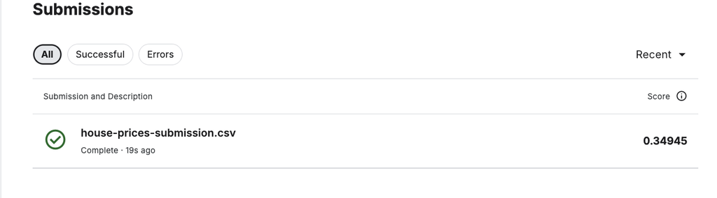

提出後の画面：今回のスコアは0.34945

今回のスコアは **0.34945** である。価格の対数に対するRMSEなので単位はなく、小さいほど良い。共通の合格点はないため、[Leaderboard](https://www.kaggle.com/competitions/house-prices-advanced-regression-techniques/leaderboard)で、同じコンペの他の参加者のスコアと比較して評価する。説明変数の追加や価格の対数変換などを試し、検証用データで比較してから再提出しよう。前回よりスコアが下がったかを確認する。

[Codeページ](https://www.kaggle.com/competitions/house-prices-advanced-regression-techniques/code)では、他の参加者が公開した分析やコードを参考にできる。データの前処理、特徴量の作り方、モデルの比較方法を学び、自分の分析に取り入れてみよう。

# 3 まとめ

今回は、すでに学んだ線形回帰を機械学習の観点から活用した。データを**学習用と検証用に分け**、モデルの**未知データに対する予測性能**を確かめたうえで、Kaggleに予測値を提出し、テストデータでの評価を受けた。

Kaggleを使う理由は、分析者がテストデータの正解を見られないためである。自分で学習用データとテストデータを分ける演習では、テストデータの正解も手元にあり、つい答えを見てモデルを調整したくなる。データを分けるだけでは、その行動までは防げない。

本講義では、正解が非公開の**テストデータで予測性能を評価すること**を重視する。手元の**検証用データでモデルを比較・調整**し、正解を知らないデータに対して、どの程度正確に予測できるかを確かめる。今後の課題では、教員のサーバーで採点する。仕組みはKaggleと同様で、テストデータの正解は公開せず、提出された予測値と正解を比較してスコアを計算する。各自が検証用データでモデルを調整し、予測スコアの改善を目指す。

今回は課題の提出はない。各自で線形回帰に使う説明変数を変えたり、多項式の項を加えて非線形な関係を表現したりしてみよう。予測結果を再びKaggleに提出し、RMSEが小さくなるかを確かめてほしい。